# NC Public Water Utilities

Kyle P Messier

2023-07-07

## North Carolina Water Utility Data Sources

1. Public Water Source Intakes These are point locations of well intakes for public water sources. I have joined these to our PFAS data using a unique EPA assigned ID

Obtained from NCOneMap at https://arcg.is/iD8vy

2. Type A Current Public Water Systems These are polygons that are supposed to represent the entire area of a public water system.

Obtained from NCOneMap at https://arcg.is/1Ge8zm

The following map shows the North Carolina Public Water systems with the colors representing their ownership types.

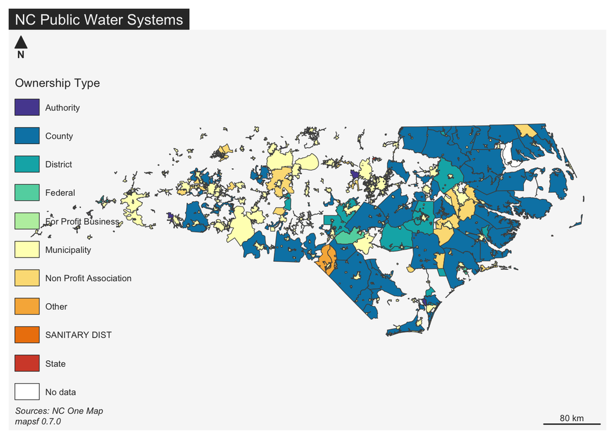

Here, we look at the PWS that are only municipal. These areas look much more in line with what I would expect as a water distribution area.

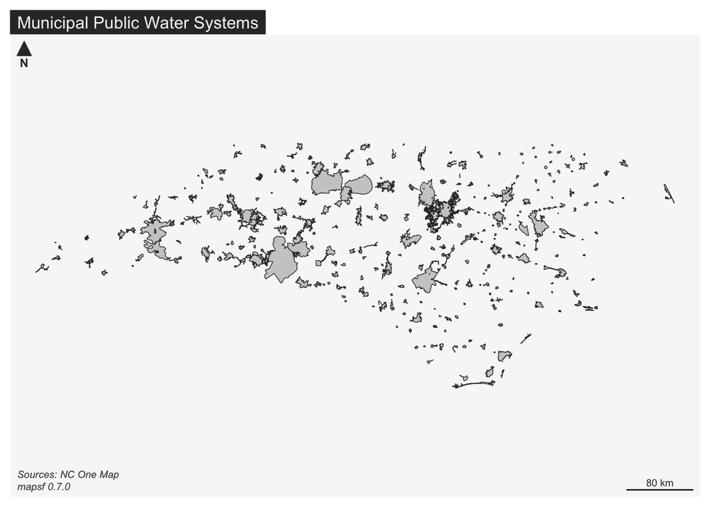

Questions:

1. Is it unlikely that an entire county would be supplied by a public water utility like those in eastern NC that are an entire county?
2. Is it normal to have a well or intake location outside the boundary of the supply area? i.e. some of the points are outside the municipal area
3. If you were to estimate the total areas in NC serviced by a public water utility, would you use just the municipal or also include some of the other ownership types?